# Deep learning et Reseaux de neurones convolutifs (CNN)

## Objectifs

- Expliquer les bases de fonctionnement des réseaus de neurones
- Expliquer le fonctionnement des réseaux de neurones convolutifs
- Appliquer le concept des CNN à une base d'images réelles pour la classification

## Plan

1. Les bases
2. CNN

## 1. Les bases

### Définition

- Le deep learning est un algorithme de machine learning basé sur des neurones artificiels.
- Les neurones sont des unités de calculs qui prennent en entrée des informations puis les transforment en une valeur et transmettent cette valeur à d'autres neurones.

### Le perceptron

- unité de base des réseaux de neurones: constitué d'un seul neurone
- L'empilement de pleusieurs unités de base, réliées entre elles forme le perceptron multicouche ou réseau de neurones

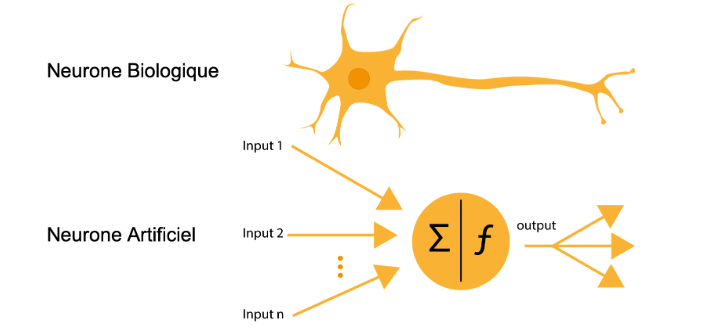

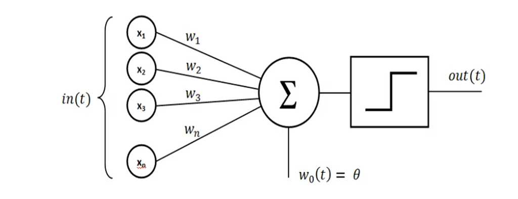

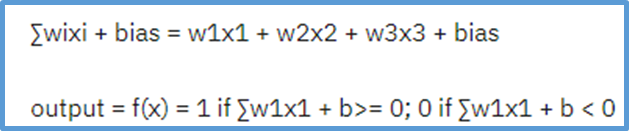

### Reseau de neurones (Artificial neural network, ANN)

- Ajout des couches intermédiaires de neurones ou couches cachées
- Nombre de couches cachées optimisables pour éviter le surapprentissage
  - ANN avec une seule couche cachée

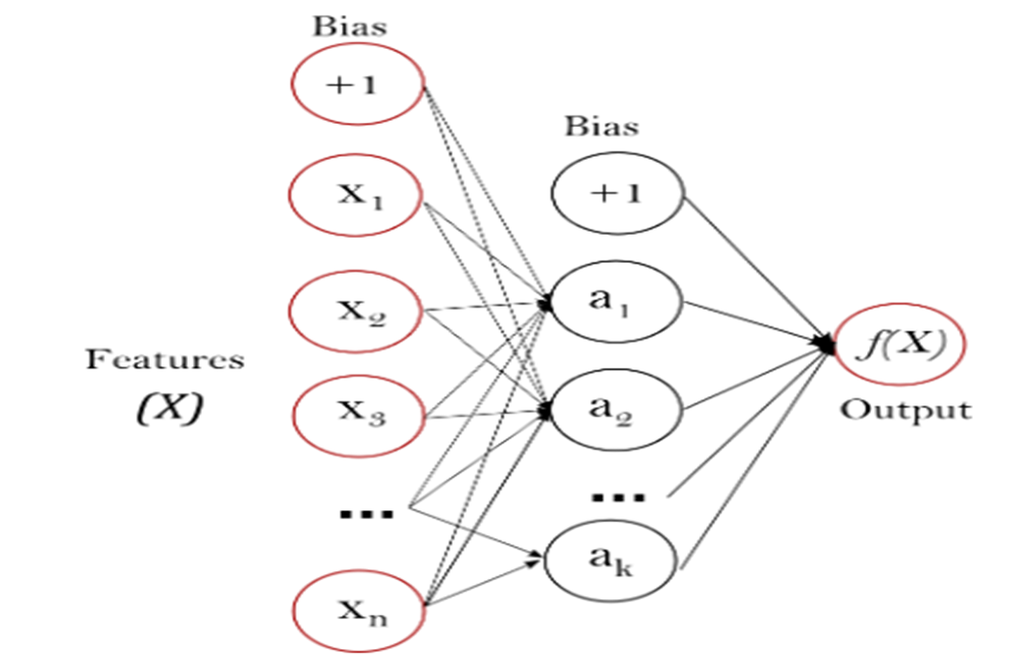

  - ANN avec deux couches cachées

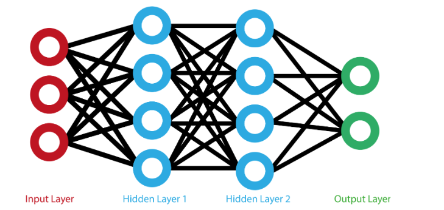

- L'avantage du deep learning réside dans la superposition de couches. Cette superposition permet de changer la représentation des données d'entrées de notre réseau pour mettre en valeur différentes caractéristiques du jeu de données. Cette nouvelle représentation est élaborée afin de résoudre plus efficacement le problème considéré.
- Cette recherche de caractéritiques internes aux données remplace en partie le processus de feature engineering indispensable aux modèles de machines learning classique.
- Cette fonctionnalité des ANN a permis de créer les modèles de deep learning robuste capable de traiter les données non structurées comme le texte, le son et les images.
  - Architectures comparées du machine learning classique et du deep learning

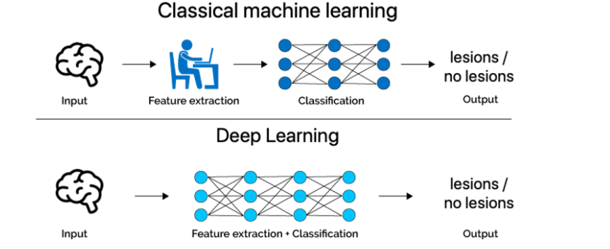

### Types d'ANN

- Réseaux de neurones à propagation vers l'avant (feedforward) : il s'agit du type d'architecture ANN le plus simple, dans lequel les informations circulent dans un sens, de l'entrée à la sortie. Les couches sont entièrement connectées, ce qui signifie que chaque neurone d'une couche est connecté à tous les neurones de la couche suivante.
- Réseaux de neurones récurrents (RNN) : ces réseaux ont un composant "mémoire", où les informations peuvent circuler par cycles à travers le réseau. Cela permet au réseau de traiter des séquences de données, telles que des séries chronologiques ou de la parole.
- Réseaux de neurones convolutifs (CNN) : ces réseaux sont conçus pour traiter des données avec une topologie en forme de grille, telles que des images. Les couches sont constituées de couches convolutionnelles, qui apprennent à détecter des caractéristiques spécifiques dans les données, et de couches de regroupement, qui réduisent les dimensions spatiales des données.
- Auto-encodeurs : ce sont des réseaux de neurones utilisés pour l'apprentissage non supervisé. Ils se composent d'un encodeur qui mappe les données d'entrée sur une représentation de dimension inférieure et d'un décodeur qui mappe la représentation sur les données d'origine.
- Réseaux antagonistes génératifs (GAN) : ce sont des réseaux de neurones utilisés pour la modélisation générative. Ils se composent de deux parties : un générateur qui apprend à générer de nouveaux échantillons de données et un discriminateur qui apprend à distinguer les données réelles des données générées.
- Le modèle d'un réseau de neurones artificiels peut être spécifié par trois entités :
  - Interconnexions
  - Fonctions d'activation
  - Règles d'apprentissage

### Interconnections

- Single-layer feed-forward network (Réseau monocouche à propagation vers l'avant)

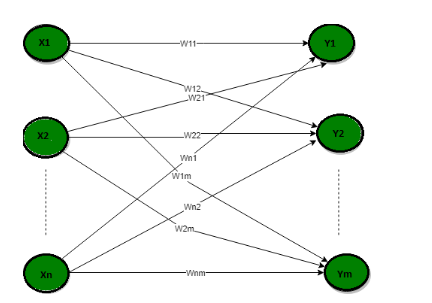

  - Dans ce type de réseau, nous n'avons que deux couches: la couche d'entrée et la couche de sortie. La couche d'entrée ne compte pas car aucun calcul n'est effectué dans cette couche. La couche de sortie est formée lorsque différents poids sont appliqués aux nœuds d'entrée et que l'effet cumulatif par nœud est pris. Après cela, les neurones donnent collectivement la couche de sortie pour calculer les signaux de sortie.
- Multilayer feed-forward network (Réseau multicouche à propagation vers l'avant)

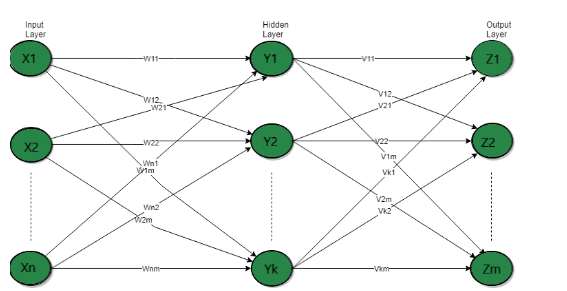

  - Cette couche possède également une couche cachée qui est interne au réseau et n'a aucun contact direct avec la couche externe. L'existence d'une ou plusieurs couches cachées permet au réseau d'être plus puissant en termes de calcul, un réseau à anticipation en raison du flux d'informations via la fonction d'entrée et des calculs intermédiaires utilisés pour déterminer la sortie Z. Il n'y a pas de connexions de rétroaction dans lesquelles les sorties du modèle est réinjecté en lui-même.
- Single node with its own feedback(Nœud unique avec sa propre rétroaction)

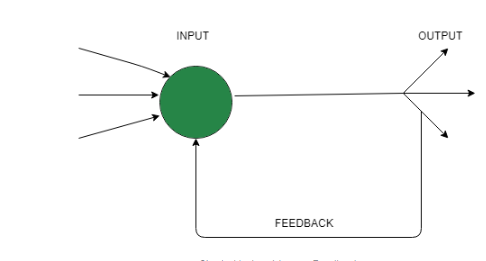

  - Lorsque les sorties peuvent être redirigées en tant qu'entrées vers la même couche ou les nœuds de couche précédents, cela se traduit par des réseaux de rétroaction. Les réseaux récurrents sont des réseaux de rétroaction avec des boucles fermées. La figure ci-dessus montre un seul réseau récurrent ayant un seul neurone avec rétroaction à lui-même.
- Single-layer recurrent network(RNN, Réseau récurrent monocouche)

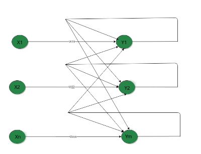

  - Le réseau ci-dessus est un réseau monocouche avec une connexion de rétroaction dans laquelle la sortie de l'élément de traitement peut être redirigée vers lui-même ou vers un autre élément de traitement ou les deux. Un réseau neuronal récurrent est une classe de réseaux neuronaux artificiels où les connexions entre les nœuds forment un graphe orienté le long d'une séquence. Cela lui permet de présenter un comportement temporel dynamique pour une séquence temporelle. Contrairement aux réseaux de neurones à propagation vers l'avant, les RNN peuvent utiliser leur état interne (mémoire) pour traiter des séquences d'entrées.
- Multilayer recurrent network(Réseau récurrent multicouche)

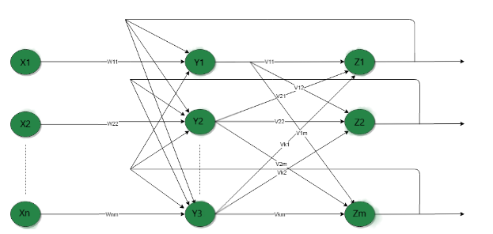

  - Dans ce type de réseau, la sortie de l'élément de traitement peut être dirigée vers l'élément de traitement dans la même couche et dans la couche précédente formant un réseau récurrent multicouche. Ils effectuent la même tâche pour chaque élément d'une séquence, la sortie dépendant des calculs précédents. Les entrées ne sont pas nécessaires à chaque étape. La principale caractéristique d'un réseau de neurones récurrent est son état caché, qui capture certaines informations sur une séquence.

### Fonctions d'activation

- La fonction d'activation décide si un neurone doit être activé ou non en calculant la somme pondérée et en y ajoutant un biais. Le but de la fonction d'activation est d'introduire une non-linéarité dans la sortie d'un neurone.
- Nous savons que le réseau de neurones a des neurones qui fonctionnent en correspondance avec le poids, le biais et leur fonction d'activation respective. Dans un réseau de neurones, on mettrait à jour les poids et les biais des neurones sur la base de l'erreur en sortie. Ce processus est connu sous le nom de rétropropagation. Les fonctions d'activation rendent la rétropropagation possible puisque les gradients sont fournis avec l'erreur pour mettre à jour les poids et les biais.
- Un réseau de neurones sans fonction d'activation n'est essentiellement qu'un modèle de régression linéaire. La fonction d'activation effectue la transformation non linéaire de l'entrée, ce qui la rend capable d'apprendre et d'effectuer des tâches plus complexes.
- Soit le réseau de neurones suivant:

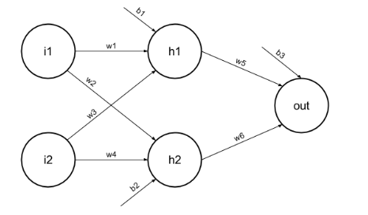

  - z(1) = W(1)X + b(1) [a(1)]
  - z(1) est la sortie vectorisée de la couche 1
  - W(1) sont les poids vectorisés attribués aux neurones de la couche cachée, c'est-à-dire w1, w2, w3 et w4
  - X soit les caractéristiques d'entrée vectorisées, c'est-à-dire i1 et i2
  - b est le biais vectorisé attribué aux neurones de la couche cachée, c'est-à-dire b1 et b2
  - a(1) est la forme vectorisée de toute fonction linéaire.
  - Pas de fonctio d'activation à ce niveau
- Pour la deuxième couche cachée et les autres couches:
  - Remarque : L'entrée pour la couche 2 est la sortie de la couche 1
  - z(2) = W(2)a(1) + b(2)
  - a(2) = z(2)
- Calcul au niveau de la couche de sortie
  - z(2) = (W(2) * [W(1)X + b(1)]) + b(2)
  - z(2) = [W(2) *W(1)]* X + [W(2)*b(1) + b(2)]
- Donc
  - [W(2) * W(1)] = W
  - [W(2)*b(1) + b(2)] = b
- Sortie finale : z(2) = W*X + b, qui est encore une fonction linéaire

Cette observation se traduit à nouveau par une fonction linéaire même après l'application d'une couche cachée, nous pouvons donc conclure que, peu importe le nombre de couches cachées que nous attachons dans le réseau neuronal, toutes les couches se comporteront de la même manière car la composition de deux fonctions linéaires est un fonction linéaire elle-même. Le neurone ne peut pas apprendre avec juste une fonction linéaire qui lui est attachée. Une fonction d'activation non linéaire lui permettra d'apprendre selon la différence avec l'erreur. Nous avons donc besoin d'une fonction d'activation.

Variantes de la fonction d'activation

- Fonction linéaire
  - Équation : La fonction linéaire a l'équation similaire à celle d'une ligne droite, c'est-à-dire y = x
  - Peu importe le nombre de couches que nous avons, si toutes sont de nature linéaire, la fonction d'activation finale de la dernière couche n'est rien d'autre qu'une fonction linéaire de l'entrée de la première couche.
  - Plage : -inf à +inf
  - Utilisations : La fonction d'activation linéaire est utilisée à un seul endroit, c'est-à-dire la couche de sortie.
  - Problèmes : Si nous différencions la fonction linéaire pour apporter de la non-linéarité, le résultat ne dépendra plus de l'entrée "x" et la fonction deviendra constante, cela n'introduira aucun comportement révolutionnaire dans notre algorithme.
  - Par exemple : Le calcul du prix d'un appartement est un problème de régression. Le prix de l'immobilier peut avoir n'importe quelle valeur grande ou petite, nous pouvons donc appliquer une activation linéaire à la couche de sortie. Même dans ce cas, le réseau neuronal doit avoir une fonction non linéaire au niveau des couches cachées.
- Fonction sigmoïde

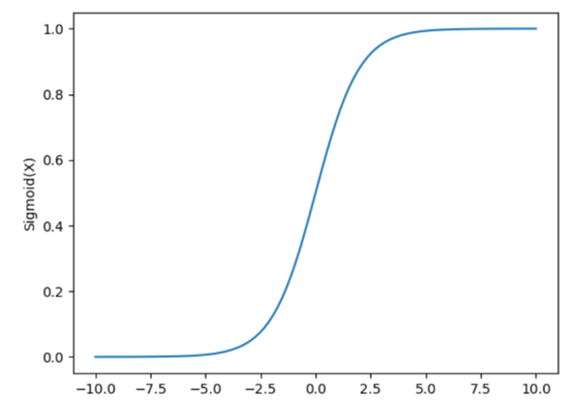

  - C'est une fonction qui est tracée sous forme de graphique en forme de « S ».
  - Équation : A = 1/(1 + exp(-x))
  - Nature : Non linéaire. Notez que pour les valeurs X se situant entre -2 et 2, les valeurs Y sont très raides. Cela signifie que de petits changements dans x entraîneraient également de grands changements dans la valeur de Y.
  - Plage de valeurs : 0 à 1
  - Utilisations : généralement utilisée dans la couche de sortie d'une classification binaire, où le résultat est 0 ou 1, car la valeur de la fonction sigmoïde se situe entre 0 et 1 uniquement. Ainsi, le résultat peut être facilement prédit comme étant 1 si la valeur est supérieure à 0,5 et 0 sinon.
- Fonction tangente hyperbolique (tanh)

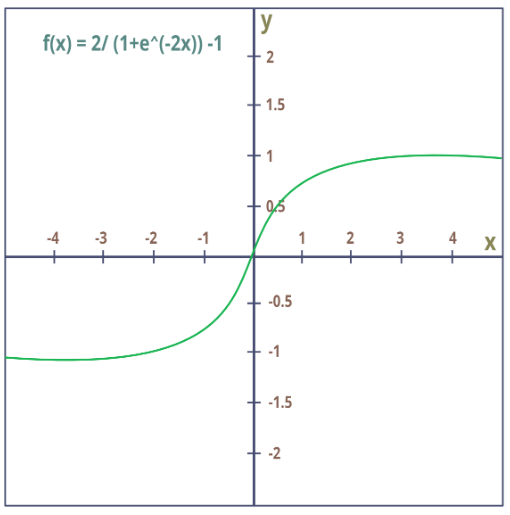

  - L'activation qui fonctionne presque toujours mieux que la fonction sigmoïde est la fonction Tanh également connue sous le nom de fonction hyperbolique tangente. C'est en fait une version mathématiquement décalée de la fonction sigmoïde. Les deux sont similaires et peuvent être dérivés l'une de l'autre.
  - Équation :

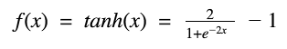

  - Plage de valeurs :-1 à +1
  - Nature :- non linéaire
  - Utilisations : - Généralement utilisée dans les couches cachées d'un réseau de neurones car ses valeurs se situent entre -1 et 1, la moyenne de la couche cachée est donc de 0 ou très proche de celle-ci, ce qui aide à centrer les données en rapprochant la moyenne de 0 Cela rend l'apprentissage de la couche suivante beaucoup plus facile.
- Fonction RELU (Rectified linear unit) ou Unité linéaire rectifiée

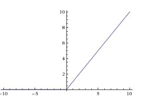

  - Il représente l'unité linéaire rectifiée. C'est la fonction d'activation la plus utilisée. Principalement mis en œuvre dans les couches cachées du réseau neuronal.
  - Équation : A(x) = max(0,x). Il donne une sortie x si x est positif et 0 sinon.
  - Plage de valeurs : [0, inf)
  - Nature : non linéaire, ce qui signifie que nous pouvons facilement rétropropager les erreurs et que plusieurs couches de neurones sont activées par la fonction ReLU.
  - Utilisations : ReLu est moins coûteux en calcul que tanh et sigmoïde car il implique des opérations mathématiques plus simples. À la fois, seuls quelques neurones sont activés, ce qui rend le réseau clairsemé, ce qui le rend efficace et facile à calculer.
  - En termes simples, RELU apprend beaucoup plus rapidement que la fonction sigmoïde et Tanh.

Fonction softmax ou fonction exponentielle normalisée

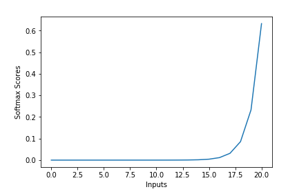

- C'est une généralisation de la fonvction logistique
- Equation:

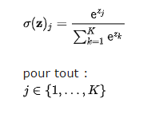

- La fonction softmax est également un type de fonction sigmoïde mais est pratique lorsque nous essayons de gérer des problèmes de classification multi-classe.
  - Nature : non linéaire
  - Utilisations : Habituellement utilisée lorsque qu'on veut gérer plusieurs classes. la fonction softmax est couramment utilisée dans la couche de sortie des problèmes de classification d'images. La fonction softmax comprime les sorties de chaque classe entre 0 et 1 et divise également par la somme des sorties.
  - Sortie : La fonction softmax est idéalement utilisée dans la couche de sortie du classificateur où nous essayons en fait de calculer les probabilités pour définir la classe de chaque entrée.

#### Choix de la fonction d'activation

- La règle de base est que si vous ne savez vraiment pas quelle fonction d'activation utiliser, utilisez simplement RELU car il s'agit d'une fonction d'activation générale dans les couches cachées et est utilisée dans la plupart des cas de nos jours.
- Si votre sortie est destinée à la classification binaire, la fonction sigmoïde est un choix très naturel pour la couche de sortie.
- Si votre sortie est destinée à une classification multi-classes, Softmax est très utile pour prédire les probabilités de chaque classe.

## 2. Les Réseaux de neurones convolutifs (CNN)

### Architecture de CNN

- Le réseau neuronal convolutif se compose de plusieurs couches telles que la couche d'entrée, la couche convolutive, la couche de regroupement et des couches entièrement connectées.

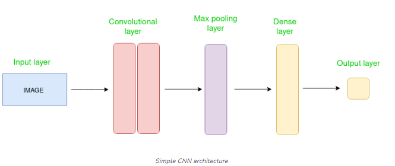

### Convolution

- Utilisation des filtres ou kernels pour extraire les principales caractéristiques de chaque image
- Les images sont constituées de pixels

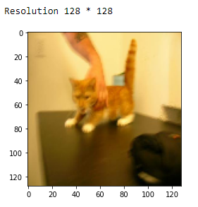

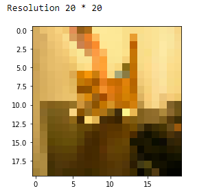

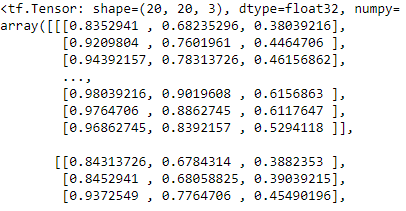

- On déplace le kernel progressivement sur l'ensemble de l'image
- On fait une somme pondérée des caractéristiques obtenues

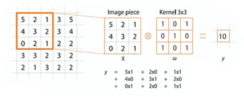

- Deux paramètres sont définis pour parcourrir les images: le padding et le strides
  - Padding (traitement des bordures avec conservation ou réduction de la taille de l'image)

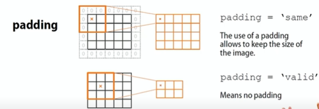

  - strides (Pas de déplacement du filtre)

[figure not shown]

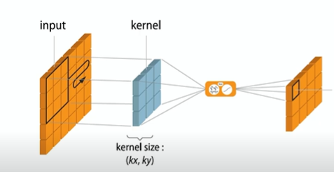

### Pooling (max)

- Prendre la valeur maximale des caracétristiques dans la zone considérée

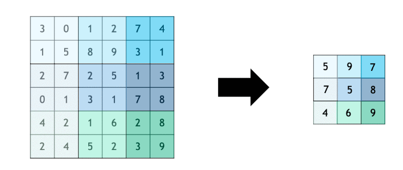

### Flatten (applatissment sur une seule dimension)

- Utilisation des caratéristiques extraites du pooling

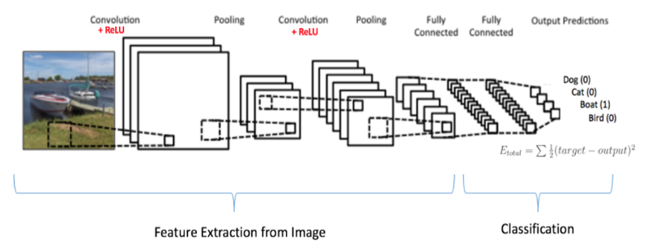

[figure not shown]